# Prediction Assignment

Juan Francisco Morales

March 8, 2019

## Background

Using devices such as Jawbone Up, Nike FuelBand, and Fitbit it is now possible to collect a large amount of data about personal activity relatively inexpensively. These type of devices are part of the quantified self movement – a group of enthusiasts who take measurements about themselves regularly to improve their health, to find patterns in their behavior, or because they are tech geeks. One thing that people regularly do is quantify how much of a particular activity they do, but they rarely quantify how well they do it. In this project, your goal will be to use data from accelerometers on the belt, forearm, arm, and dumbell of 6 participants. They were asked to perform barbell lifts correctly and incorrectly in 5 different ways. More information is available from the website here: http://groupware.les.inf.puc-rio.br/har (see the section on the Weight Lifting Exercise Dataset).

## Goal

The goal of the project is to predict the manner in which they did the exercise. This is the “classe” variable in the training set.

## Reading, exploring and cleaning the data

This part is for setting the data for modeling purposes.

```r
library(data.table)

library(caret)
```

```r
url.train <- "https://d396qusza40orc.cloudfront.net/predmachlearn/pml-training.csv"

url.test <- "https://d396qusza40orc.cloudfront.net/predmachlearn/pml-testing.csv"

training <- as.data.frame(fread( url.train , na.strings = c("NA" , "#DIV/0!") ))

str(training)
```

```
## 'data.frame':    19622 obs. of  160 variables:
##  $ V1                      : int  1 2 3 4 5 6 7 8 9 10 ...
##  $ user_name               : chr  "carlitos" "carlitos" "carlitos" "carlitos" ...
##  $ raw_timestamp_part_1    : int  1323084231 1323084231 1323084231 1323084232 1323084232 1323084232 1323084232 1323084232 1323084232 1323084232 ...
##  $ raw_timestamp_part_2    : int  788290 808298 820366 120339 196328 304277 368296 440390 484323 484434 ...
##  $ cvtd_timestamp          : chr  "05/12/2011 11:23" "05/12/2011 11:23" "05/12/2011 11:23" "05/12/2011 11:23" ...
##  $ new_window              : chr  "no" "no" "no" "no" ...
##  $ num_window              : int  11 11 11 12 12 12 12 12 12 12 ...
##  $ roll_belt               : num  1.41 1.41 1.42 1.48 1.48 1.45 1.42 1.42 1.43 1.45 ...
##  $ pitch_belt              : num  8.07 8.07 8.07 8.05 8.07 8.06 8.09 8.13 8.16 8.17 ...
##  $ yaw_belt                : num  -94.4 -94.4 -94.4 -94.4 -94.4 -94.4 -94.4 -94.4 -94.4 -94.4 ...
##  $ total_accel_belt        : int  3 3 3 3 3 3 3 3 3 3 ...
##  $ kurtosis_roll_belt      : num  NA NA NA NA NA NA NA NA NA NA ...
##  $ kurtosis_picth_belt     : num  NA NA NA NA NA NA NA NA NA NA ...
##  $ kurtosis_yaw_belt       : num  NA NA NA NA NA NA NA NA NA NA ...
```

[output cut: 86 more lines]

```r
colnames(training)
```

```
##   [1] "V1"                       "user_name"
##   [3] "raw_timestamp_part_1"     "raw_timestamp_part_2"
##   [5] "cvtd_timestamp"           "new_window"
##   [7] "num_window"               "roll_belt"
##   [9] "pitch_belt"               "yaw_belt"
##  [11] "total_accel_belt"         "kurtosis_roll_belt"
##  [13] "kurtosis_picth_belt"      "kurtosis_yaw_belt"
##  [15] "skewness_roll_belt"       "skewness_roll_belt.1"
##  [17] "skewness_yaw_belt"        "max_roll_belt"
##  [19] "max_picth_belt"           "max_yaw_belt"
##  [21] "min_roll_belt"            "min_pitch_belt"
##  [23] "min_yaw_belt"             "amplitude_roll_belt"
##  [25] "amplitude_pitch_belt"     "amplitude_yaw_belt"
##  [27] "var_total_accel_belt"     "avg_roll_belt"
##  [29] "stddev_roll_belt"         "var_roll_belt"
```

[output cut: 65 more lines]

```r
training <- training[,-c(1:7)] # Drop features that I will not use

training <- training[ , apply(training, 2, function(x) !any(is.na(x)))] ### Drop columns with NA

training$classe <- as.factor(make.names(training$classe))

test <- as.data.frame(fread(url.test, na.strings = c("NA" , "#DIV/0!") ))
```

## Parallelization setting

I do parallelization in order to make the model development faster.

```r
library(parallel)

library(doParallel)
set.seed(1)


cores <- detectCores()

cls = makeCluster(cores)

registerDoParallel(cls)

seeds <- vector(mode = "list", length = 1000)

for(i in 1:length(seeds)) seeds[[i]] <- sample.int(1000, 1000)
```

## Cross-validation setting

For model optimization I use K-fold cross validation with K = 10.

```r
ctrl <- trainControl(method="cv",

                     allowParallel = TRUE,

                     seeds = seeds,

                     verboseIter = FALSE ,

                     number = 10 ,

                     classProbs=TRUE

)
```

## Grid search setting

I set the model parameters to be optimize.

```r
gbmGrid <-  expand.grid(

  interaction.depth = 3 ,

  n.trees = seq(from = 500 , to = 3000 , by = 500),

  shrinkage = 0.1 ,

  n.minobsinnode = 10 )
```

## Model training and optimization

Training and optimization model procedure itself

```r
gbmfit <- train(classe ~ .,

                data = training,

                method = "gbm",

                trControl = ctrl,

                tuneGrid = gbmGrid,

                verbose = FALSE
)


stopCluster(cls)
```

## Final model and optimization results

The final model is printed and the optimization results are plotted.

```r
gbmfit
```

```
## Stochastic Gradient Boosting
##
## 19622 samples
##    52 predictor
##     5 classes: 'A', 'B', 'C', 'D', 'E'
##
## No pre-processing
## Resampling: Cross-Validated (10 fold)
## Summary of sample sizes: 17662, 17659, 17660, 17660, 17659, 17659, ...
## Resampling results across tuning parameters:
##
##   n.trees  Accuracy   Kappa
##    500     0.9924580  0.9904601
##   1000     0.9956683  0.9945208
##   1500     0.9961269  0.9951011
##   2000     0.9965345  0.9956165
##   2500     0.9968402  0.9960031
##   3000     0.9968402  0.9960032
##
## Tuning parameter 'interaction.depth' was held constant at a value of
##  3
## Tuning parameter 'shrinkage' was held constant at a value of 0.1
##
## Tuning parameter 'n.minobsinnode' was held constant at a value of 10
## Accuracy was used to select the optimal model using the largest value.
## The final values used for the model were n.trees = 2500,
##  interaction.depth = 3, shrinkage = 0.1 and n.minobsinnode = 10.
```

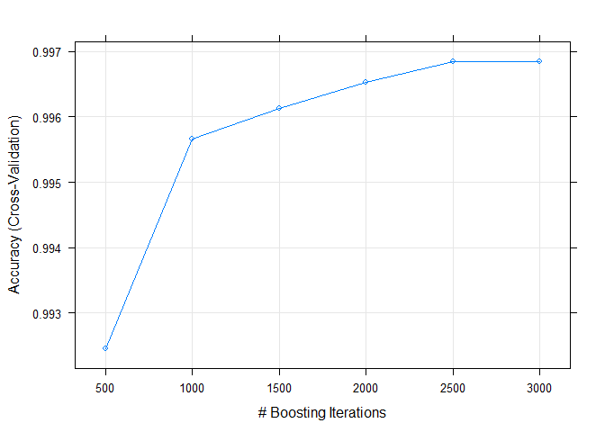

```r
plot(gbmfit)
```

## Results in the training set

The accuracy in the training set is printed.

```r
train.pred <- predict(gbmfit, newdata = training , na.action = na.pass)

confusionMatrix(data =  train.pred , reference = training$classe )
```

```
## Confusion Matrix and Statistics
##
##           Reference
## Prediction    A    B    C    D    E
##          A 5580    0    0    0    0
##          B    0 3797    0    0    0
##          C    0    0 3422    0    0
##          D    0    0    0 3216    0
##          E    0    0    0    0 3607
##
## Overall Statistics
##
##                Accuracy : 1
##                  95% CI : (0.9998, 1)
##     No Information Rate : 0.2844
##     P-Value [Acc > NIR] : < 2.2e-16
##
##                   Kappa : 1
##  Mcnemar's Test P-Value : NA
##
## Statistics by Class:
##
##                      Class: A Class: B Class: C Class: D Class: E
## Sensitivity            1.0000   1.0000   1.0000   1.0000   1.0000
## Specificity            1.0000   1.0000   1.0000   1.0000   1.0000
## Pos Pred Value         1.0000   1.0000   1.0000   1.0000   1.0000
## Neg Pred Value         1.0000   1.0000   1.0000   1.0000   1.0000
## Prevalence             0.2844   0.1935   0.1744   0.1639   0.1838
## Detection Rate         0.2844   0.1935   0.1744   0.1639   0.1838
## Detection Prevalence   0.2844   0.1935   0.1744   0.1639   0.1838
## Balanced Accuracy      1.0000   1.0000   1.0000   1.0000   1.0000
```

## Expected out of sample error

The expected out of sample accuracy is printed. I based on the K-fold cross validation results.

```r
getTrainPerf(gbmfit)
```

```
##   TrainAccuracy TrainKappa method
## 1     0.9968402  0.9960031    gbm
```

## Predictions in the test set

Predictions in the test set are printed.

```r
test.pred <- predict(gbmfit, newdata = test, na.action = na.pass)

cbind(problem_id = test$problem_id ,model_prediction =  as.character(test.pred))
```

```
##       problem_id model_prediction
##  [1,] "1"        "B"
##  [2,] "2"        "A"
##  [3,] "3"        "B"
##  [4,] "4"        "A"
##  [5,] "5"        "A"
##  [6,] "6"        "E"
##  [7,] "7"        "D"
##  [8,] "8"        "B"
##  [9,] "9"        "A"
## [10,] "10"       "A"
## [11,] "11"       "B"
## [12,] "12"       "C"
## [13,] "13"       "B"
## [14,] "14"       "A"
## [15,] "15"       "E"
## [16,] "16"       "E"
## [17,] "17"       "A"
## [18,] "18"       "B"
## [19,] "19"       "B"
## [20,] "20"       "B"
```